# Grattan Institute

Hugh Parsonage

2021-01-29

## Budget 2018

For a vignette from the Budget 2018 analysis, see: https://hughparsonage.github.io/grattan/articles/long-vignettes/budget-2018.html

This vignette collates the vignettes that were present before version 1.5.3.

To run the vignette, provided you have access to the Internet, set the environment variable `R_GRATTAN_BUILD_MAIN_VIGNETTE` to `"true"`. (It is set off to satisfy CRAN requirements.)

# Bracket creep

```r
library(hutilscpp)
library(mgcv)
library(lattice)
library(dtplyr)
library(dplyr)
```

```r
library(ggplot2)
library(scales)
library(ggrepel)
library(viridis)
library(knitr)
library(hutils)
library(magrittr)
library(data.table)
```

```r
library(grattan)
```

```r
require_taxstats()
require_taxstats1516()
```

```r
sample_files_all <- get_sample_files_all()
sample_files_all[, WEIGHT := if_else(fy.year > '2010-11', 50L, 100L)]
age_range_decoder <- as.data.table(age_range_decoder)
```

```r
# Just an easy way to grab a bit of extra memory
weighted.mean <- function(x, w) {
  sum(as.double(x) * w) / sum(x)
}
```

## Introduction

This vignette uses a [recent op-ed](https://grattan.edu.au/news/young-australians-will-wear-the-costs-of-turnbulls-middle-income-tax-cut/) to demonstrate several tools within the `grattan` package:

1. projection of sample files for analysis over the budget forward estimates, including a flexible assumption about future wage growth
2. calculating income tax, both under present settings and changes to thresholds or rates.

### Average change of tax rates by decile

Say we want to compare the expected income tax paid by individuals in 2016-17 vs 2020-21. We have 2% sample files from 2012-13 and 2013-14. To do distributional analysis for years beyond 2013-14, we `project` a sample file as many years ahead as required. So for 2016-17, we use `project` with `h = 4L`. (The `h` stands for ‘’horizon’‘. The `L` means ’integer’ in R: `project` insists that the `h` value is strictly an integer as that is the only type of value that makes sense here.)

```r
sample_file_1617 <-
  project(sample_file_1213,
          h = 4L,
          fy.year.of.sample.file = "2012-13")
```

and similarly for 2020-21 we use `h = 8L`:

```r
sample_file_2021 <-
  project(sample_file_1213,
          h = 8L,
          fy.year.of.sample.file = "2012-13")
```

I use `fy.year.of.sample.file = "2012-13"` rather than `= "2013-14"` as the former seems to give more accurate forecasts when compared with final budget outcomes in the years that follow.

The next step is to calculate the tax paid for each entry in the sample file for those years. The `grattan` package provides `income_tax` for this purpose, with the optional argument `.dots.ATO` accepting a sample file to take care of the variables that are needed for the complex calculations of offsets and the Medicare levy. The argument `fy.year` specifies what tax scales to use; for future years, we assume the current settings, unless the Government has announced changes in a future year, such as the expected increase to the Medicare levy. Since the `income_tax` function only currently works for years as far ahead as 2019-20, we use that year for the 2020-21 projection of the sample file.

```r
sample_file_1617[, tax_paid := income_tax(Taxable_Income,
                                          .dots.ATO = copy(sample_file_1617),
                                          fy.year = "2016-17")]
sample_file_1617[, avg_tax := tax_paid / Taxable_Income]
sample_file_2021[, tax_paid := income_tax(Taxable_Income,
                                          .dots.ATO = copy(sample_file_2021),
                                          fy.year = "2019-20")]
sample_file_2021[, avg_tax := tax_paid / Taxable_Income]
```

To calculate the average (average) tax by decile, we use `weighted_ntile` with the optional arguments `weights` left to the default (as the sample file is equiweighted).

```r
avg_tax_by_decile_1617 <-
  sample_file_1617 %>%
  .[, .(avg_tax = mean(avg_tax)),
    keyby = .(decile = weighted_ntile(Taxable_Income, n = 10))]

avg_tax_by_decile_2021 <-
  sample_file_2021 %>%
  .[, .(avg_tax = mean(avg_tax)),
    keyby = .(decile = weighted_ntile(Taxable_Income, n = 10))]
```

We can then plot a comparison of these table by joining them and using `ggplot2`. Since the tables are already keyed by `decile`, we can use the `X[Y]` method from `data.table` to join by `decile`. This creates a three-column table: the first is `decile`, the second is `avg_tax` which is the `avg_tax` from the 2016-17 table and `i.avg_tax` which is the `avg_tax` from the 2020-21 table. (In the result of `X[Y]`, any column in `Y` which has the same name as a column in `X` (but isn’t a key) is prefixed with `i.` to distinguish it.) We discard the lowest decile as the average tax is `NaN` for those with zero taxable income. Lastly, for cosmetic reasons, we convert `decile` to a factor so that the labels on the chart are `1, 2, 3, ...` rather than `0, 2.5, 5, ...`.

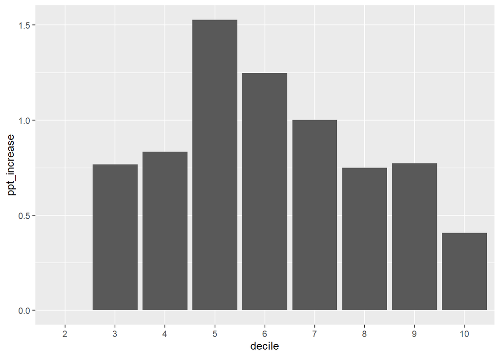

```r
avg_tax_by_decile_1617[avg_tax_by_decile_2021] %>%
  .[decile > 1] %>%
  .[, ppt_increase := 100*(i.avg_tax - avg_tax)] %>%
  .[, decile := factor(decile)] %>%
  ggplot(aes(x = decile, y = ppt_increase)) +
  geom_col()
```

This chart and the underlying data are a reflection of the assumptions in the `project` function. In particular, the `project` function uses a particular forecast of the wage price index to uprate the salary column in the sample file. This differs from the assumptions in the 2017 Budget.

```r
Budget_wage_series <-
  data.table(fy_year = c("2017-18", "2018-19", "2019-20", "2020-21"),
             r = c(0.025, 0.03, 0.035, 0.0375))

kable(Budget_wage_series)
```

| fy_year | r |
| --- | --- |
| 2017-18 | 0.0250 |
| 2018-19 | 0.0300 |
| 2019-20 | 0.0350 |
| 2020-21 | 0.0375 |

The `project` function expects wages to grow by 8% over the period 2016-17 to 2020-21, whereas by the forecast in the Budget this number would be 13%. Whatever the merits of each forecast, the `project` function allows you to specify a particular wage series in the future through the argument `wage.series =`. We can then repeat the analysis above using those estimates:

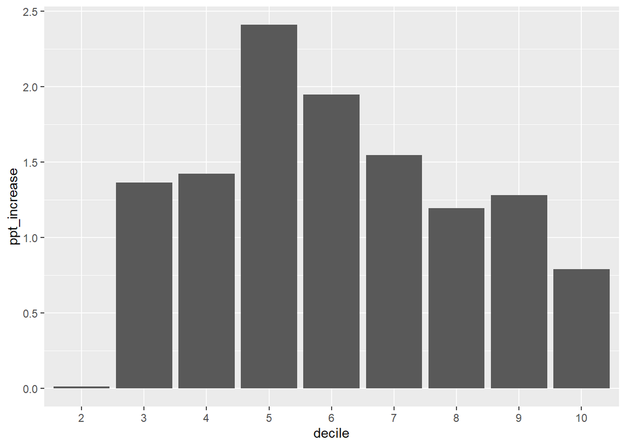

```r
sample_file_1617 <- project(sample_file_1213,
                            h = 4L,
                            fy.year.of.sample.file = "2012-13")

sample_file_2021 <- project(sample_file_1213,
                            fy.year.of.sample.file = "2012-13",
                            h = 8L,
                            wage.series = Budget_wage_series)

sample_file_1617[, tax_paid := income_tax(Taxable_Income,
                                          .dots.ATO = copy(sample_file_1617),
                                          fy.year = "2016-17")]
sample_file_1617[, avg_tax := tax_paid / Taxable_Income]
sample_file_2021[, tax_paid := income_tax(Taxable_Income,
                                          .dots.ATO = copy(sample_file_2021),
                                          fy.year = "2019-20")]
sample_file_2021[, avg_tax := tax_paid / Taxable_Income]

avg_tax_by_decile_1617 <-
  sample_file_1617 %>%
  .[, .(avg_tax = mean(avg_tax)),
    keyby = .(decile = weighted_ntile(Taxable_Income, n = 10))]

avg_tax_by_decile_2021 <-
  sample_file_2021 %>%
  .[, .(avg_tax = mean(avg_tax)),
    keyby = .(decile = weighted_ntile(Taxable_Income, n = 10))]

difference_2021_Budget <-
  avg_tax_by_decile_1617[avg_tax_by_decile_2021] %>%
  .[decile > 1] %>%
  .[, ppt_increase := 100*(i.avg_tax - avg_tax)]

difference_2021_Budget %>%
  copy %>%
  .[, decile := factor(decile)] %>%
  ggplot(aes(x = decile, y = ppt_increase)) +
  geom_col()
```

Through some intermediate calculations, we can obtain the sentence that was used in the op-ed:

```r
middle_income_avg_inc <-
  difference_2021_Budget %>%
  .[decile %between% c(3, 7)] %$%
  range(round(ppt_increase, 1))
```

```r
sample_file_1617[, percentile := weighted_ntile(Taxable_Income, n = 100)]
stopifnot(56 %in% sample_file_1617[Taxable_Income %between% c(49500, 50500)][["percentile"]])

avg_tax_rate_2017_50k <-
  sample_file_1617[percentile == 56] %$%
  mean(avg_tax) %>%
  round(3)

avg_tax_rate_2021_50k <-
  sample_file_2021 %>%
  .[, percentile := weighted_ntile(Taxable_Income, n = 100)] %>%
  .[percentile == 56] %$%
  mean(avg_tax) %>%
  round(3)
```

### Income tax with changes to rates

We can also use the package to estimate the revenue difference under changes to the marginal tax rates. The following function accepts two arguments: the bracket number to modified, and a rate increase to that bracket. The function returns the change in revenue (as a loss).

```r
tax_delta <- function(bracket_number, rate_increase = -0.01) {
  current_tax <-
    sample_file_2021[, .(tax = sum(tax_paid),
                         WEIGHT = WEIGHT[1])] %$%
    sum(tax * WEIGHT)

  orig_rates <- c(0, 0.19, 0.325, 0.37, 0.45)
  new_rates <- orig_rates
  new_rates[bracket_number] <- new_rates[bracket_number] + rate_increase

  # rebate_income is an internal function
  .ri <- grattan:::rebate_income

  new_tax <-
    sample_file_2021 %>%
    # memory is tight on e.g. Travis-CI
    selector(cols = c("age_range",
                      "Net_rent_amt",
                      "Rep_frng_ben_amt",
                      "Spouse_adjusted_taxable_inc",
                      "Net_fincl_invstmt_lss_amt",
                      "Rptbl_Empr_spr_cont_amt",
                      "Taxable_Income",
                      "WEIGHT",
                      "tax_paid")) %>%
    .[, base_tax. := IncomeTax(Taxable_Income,
                              thresholds = c(0, 18200, 37000, 87000, 180e3),
                              rates = new_rates)] %>%
    .[, medicare_levy. := medicare_levy(income = Taxable_Income,
                                        fy.year = "2019-20",
                                        Spouse_income = Spouse_adjusted_taxable_inc,
                                        sapto.eligible = (age_range <= 1),
                                        family_status = if_else(Spouse_adjusted_taxable_inc > 0, "family", "individual"))] %>%
    .[, lito. := lito(Taxable_Income, max_lito = 445, lito_taper = 0.015, min_bracket = 37000)] %>%
    .[, rebate_income := .ri(Taxable_Income,
                             Rptbl_Empr_spr_cont_amt = Rptbl_Empr_spr_cont_amt,
                             Net_fincl_invstmt_lss_amt = Net_fincl_invstmt_lss_amt,
                             Net_rent_amt = Net_rent_amt,
                             Rep_frng_ben_amt = Rep_frng_ben_amt)] %>%
    .[, sapto. := sapto(rebate_income, fy.year = "2019-20", sapto.eligible = (age_range <= 1))] %>%
    .[, tax_payable := pmaxC(base_tax. - lito. - sapto., 0) + medicare_levy.] %>%
    .[, .(tax = sum(tax_payable),
          WEIGHT = WEIGHT[1])] %$%
    sum(tax * WEIGHT)

  current_tax - new_tax
}
```

which leads to the sentence and table in the op-ed:

```r
data.table(tax_bracket = c("<18,200",
                           "18,200-37,000",
                           "37,000-87,000",
                           "87,000-180,000",
                           "180,000+"),
           budget_impact = c(NA, round(vapply(2:5, tax_delta, FUN.VALUE = double(1)) / 1e9, 2))) %>%
  kable
```

| tax_bracket | budget_impact |
| --- | --- |
| <18,200 | NA |
| 18,200-37,000 | 1.20 |
| 37,000-87,000 | 2.19 |
| 87,000-180,000 | 0.73 |
| 180,000+ | 0.24 |

# Companion to the 2013-14 sample file

## Prologue

This vignette is a mirror of a small book prepared internally by Grattan Institute. The goal is to demonstrate how to perform simple analysis and create common charts. You will need the `taxstats` package available via `devtools::install_github('hughparsonage/taxstats')`.

```r
options("scipen" = 99)
opts_chunk$set(fig.width = 9,
               fig.height = 6.5,
               warn = FALSE)
```

```r
FY.YEAR <- "2013-14"
```

```r
wsum <- function(x, w = 1){
  sum((x) * w)
}
```

```r
grattan_dollar <- function (x, digits = 0) {
  #
  nsmall <- digits
  commaz <- format(abs(x), nsmall = nsmall, trim = TRUE, big.mark = ",",
                   scientific = FALSE, digits = 1L)

  if_else(x < 0,
          paste0("\U2212","$", commaz),
          paste0("$", commaz))
}
```

```r
sample_file <- sample_files_all[fy.year == FY.YEAR]
sample_file <- merge(sample_file, age_range_decoder, by = "age_range")
PREV.FY.YEAR <- yr2fy(fy2yr(FY.YEAR) - 1)
sample_file_prev <- sample_files_all[fy.year == PREV.FY.YEAR]
sample_file_prev <- merge(sample_file_prev, age_range_decoder, by = "age_range")
```

```r
impute_ages <- function(DT) {
  age_range_description <- NULL
  DT[grepl("to", age_range_description), min_age := as.integer(sub("^([0-9]+).*$", "\\1", age_range_description))]
  DT[grepl("70", age_range_description), min_age := 70L]
  DT[, min_age := coalesce(min_age, 15L)]
  DT[, max_age := min_age + 5L]
  if (requireNamespace("withr", quietly = TRUE)) {
    withr::with_seed(48031, {
      DT[, age_imp := runif(.N, min_age, max_age), by = .(min_age)]
    })
  } else {
    DT[, age_imp := runif(.N, min_age, max_age), by = .(min_age)]
  }
  DT[, c("min_age", "max_age") := NULL]
  DT[]
}
```

```r
impute_ages(sample_file)
```

[output not shown]

[output cut: 213 more lines]

```r
sample_file[, Tax_Bracket := cut(Taxable_Income,
                                 breaks = c(-Inf, 18200, 37e3, 80e3, 180e3, Inf),
                                 include.lowest = TRUE,
                                 labels = c("$0-$18,200",
                                            "$18,201-$37,000",
                                            "37,001-$80,000",
                                            "$80,001-$180,000",
                                            "$180,000+"))]
```

```r
texNum <- function(number, sig.figs = 3L, dollar = FALSE, pre.phrase = NULL, .suffix = NULL){
  orig.number <- number
  stopifnot(is.numeric(number), length(number) == 1L)
  is.negative <- number < 0
  number <- abs(number)
  if (number == 0){
    warning("Returning 0")
    return(0)
  } else {
    if (is.null(.suffix)){
    n.digits <- ceiling(log10(number))

    suffix <- NULL
    suffix_val <- 1

    if (n.digits < sig.figs){
      prefix <- signif(x = number, digits = sig.figs)
    } else {

      if (n.digits <= 6) {
        prefix_val <- round(number, sig.figs - n.digits - 1)
        prefix <- prettyNum(prefix_val, big.mark = ",", scientific = FALSE)
      } else {
        # Want to show only the number / 10^(multiple of 3) then the suffix multiplier
        suffix_val <- 10 ^ (3 * ((n.digits %/% 3)))
        prefix_val <- signif(number/suffix_val, digits = sig.figs)
        prefix <- prefix_val

        if (suffix_val <= 10^12){
          switch(log10(suffix_val) / 3 - 1,
                 suffix <- "~million",
                 suffix <- "~billion",
                 suffix <- "~trillion")
        } else {
          prefix <- signif(number / 10^12, digits = sig.figs)
          suffix <- "~trillion"
        }
      }
    }
    } else {
      stopifnot(.suffix %in% c("million", "billion", "trillion"))
      switch(.suffix,
             "million" = {
              prefix <- signif(number / 10^6, digits = sig.figs)
              suffix <- "~million"
              suffix_val <- 10^6
             },
             "billion" = {
               prefix <- signif(number / 10^9, digits = sig.figs)
               suffix <- "~billion"
               suffix_val <- 10^9
             },
             "trillion" = {
               prefix <- signif(number / 10^12, digits = sig.figs)
               suffix <- "~trillion"
               suffix_val <- 10^12
             })
      prefix_val <- prefix
    }

    if (dollar){
      out <- paste0("\\$", prefix, suffix)
    } else {
      out <- paste0(prefix, suffix)
    }

    if (is.negative){
      # General LaTeX
      out <- paste0("\\(-\\)", out)
    }
    # is the displayed number larger than the original?
    if (!is.null(pre.phrase)){
      out_larger <- prefix_val * suffix_val > orig.number

        if (out_larger) {
          out <- paste(pre.phrase[1], out, sep = if(grepl("~$", pre.phrase[1])) "" else " ")
        } else {
          if (!isTRUE(all.equal(prefix_val * suffix_val,
                                orig.number,
                                tolerance = .Machine$double.eps)))
            out <- paste(pre.phrase[2], out, sep = if(grepl("~$", pre.phrase[2])) "" else " ")
        }

    }
    return(out)
  }
}
sample_file <- as.data.table(sample_file)
```

There were 12.9~million taxpayers in 2013-14 in Australia. Of those, 180,000 had zero taxable income (or a taxable loss). (… and so these ‘’taxpayers’’ naturally paid no tax. Nor did the 2.5~million individuals below the tax-free threshold. For this vignette, a *taxpayer* is anyone who lodged a tax return, regardless of their tax liability).

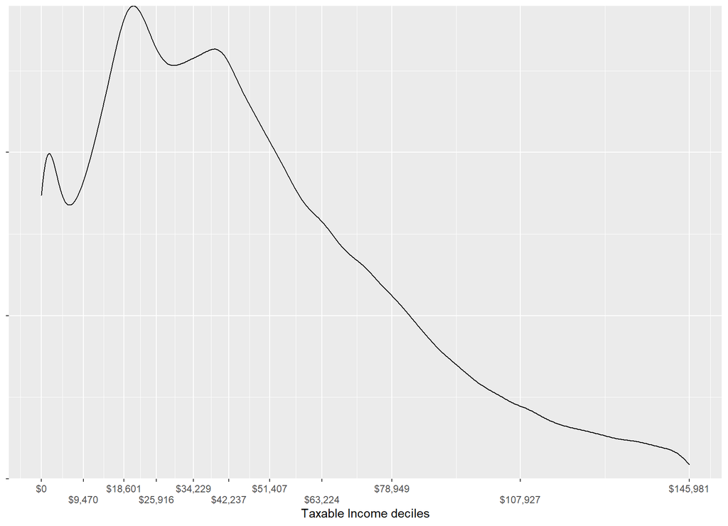

```r
tx_inc_q <- function(q){
  quantile(sample_file$Taxable_Income, probs = q)
}

my_labs <- grattan_dollar(tx_inc_q((0:10)/10))
my_labs[seq(2, 10, 2)] <- paste0("\n", my_labs[seq(2, 10, 2)])

dens <- density(sample_file[Taxable_Income < tx_inc_q(0.95)]$Taxable_Income)
DF <- with(dens, data.frame(x, y))

sample_file %>%
  lazy_dt %>%
  mutate(Taxable_Income_decile = ntile(Taxable_Income, 10)) %>%
  filter(between(Taxable_Income, 0, tx_inc_q(0.95))) %>%
  as.data.table %>%
  ggplot(aes(x = Taxable_Income)) +
  geom_density() +
  scale_fill_viridis(discrete = TRUE) +
  scale_x_continuous("Taxable Income deciles",
                     labels = c(my_labs, grattan_dollar(tx_inc_q(0.95))),
                     # limits = c(0, tx_inc_q(0.95)),
                     breaks = c(tx_inc_q((0:10)/10), tx_inc_q(0.95))) +
  scale_y_continuous(expand = c(0,0)) +
  theme(legend.position = "none",
        axis.line.y = element_blank(),
        axis.text.y = element_blank(),
        axis.title.y = element_blank())
```

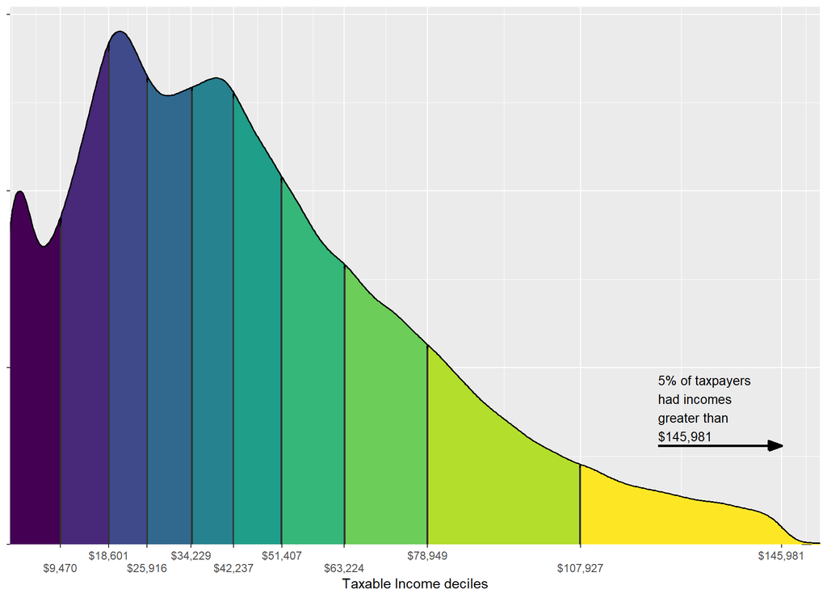

```r
DF %>%
  mutate(Taxable_Income_decile = cut(x,
                                     breaks = quantile(sample_file$Taxable_Income,
                                                       probs = c(0:10)/10),
                                     right = TRUE,
                                     include.lowest = TRUE)) %>%
  filter(between(x, -1, tx_inc_q(0.95) * 1.05)) %>%
  {
    ggplot(., aes(x = x, y = y)) +
      geom_area(color = "black", size = 1.45) +
      geom_area(aes(x = x, y = y,
                    group = Taxable_Income_decile,
                    fill = factor(Taxable_Income_decile),
                    color = factor(Taxable_Income_decile))) +
      scale_color_viridis(discrete = TRUE) +
      scale_fill_viridis(discrete = TRUE) +
      scale_x_continuous("Taxable Income deciles",
                         labels = c(my_labs, grattan_dollar(tx_inc_q(0.95))),
                         expand = c(0,0),
                         # limits = c(-1, tx_inc_q(0.95)*1.05),
                         breaks = c(tx_inc_q((0:10)/10), tx_inc_q(0.95))) +
      scale_y_continuous(expand = c(0,0), limits = c(0, max(.$y) * 1.05)) +
  theme(legend.position = "none",
        axis.line.y = element_blank(),
        axis.text.y = element_blank(),
        axis.title.y = element_blank())+

      annotate("text",
               x = tx_inc_q(0.925),
               y = 2 * max(.$y[.$x > tx_inc_q(0.925)]),
               size = 10/(14/5),
               label = paste0("5% of taxpayers\nhad incomes\ngreater than\n", grattan_dollar(tx_inc_q(0.95))),
               hjust = 0,
               vjust = 0) +
      annotate("segment",
               arrow = arrow(type = "closed", length = unit(11, "pt"), angle = 20),
               x = tx_inc_q(0.925),
               y = 1.9 * max(.$y[.$x > tx_inc_q(0.925)]),
               size = 1,
               xend = tx_inc_q(0.95),
               yend = 1.9 * max(.$y[.$x > tx_inc_q(0.925)]))
  }
```

```r
sample_file <- as.data.table(sample_file)
n_CGs <-
  sample_file %>%
  filter(Tot_CY_CG_amt > 0) %$%
  sum(WEIGHT)
n_CGs_prev <-
  sample_file_prev %>%
  filter(Tot_CY_CG_amt > 0) %$%
  sum(WEIGHT)
tot_CG_amt <-
  sample_file %$%
  sum(as.numeric(Tot_CY_CG_amt * WEIGHT))

tot_Net_CG_amt <-
  sample_file %$%
  sum(as.numeric(Net_CG_amt * WEIGHT))

tax_on_CG <-
  sample_file %>%
  filter(Net_CG_amt > 0) %>%
  mutate(tax = income_tax(Taxable_Income, fy.year = FY.YEAR),
         tax_wo_CG = income_tax(pmaxC(Taxable_Income - Net_CG_amt, 0), fy.year = FY.YEAR)) %>%
  summarise(total = sum((tax - tax_wo_CG) * WEIGHT),
            avg = mean(tax - tax_wo_CG))


tax_on_CG_prev <-
  sample_file_prev %>%
  lazy_dt %>%
  filter(Net_CG_amt > 0) %>%
  mutate(tax = income_tax(Taxable_Income, fy.year = FY.YEAR),
         tax_wo_CG = income_tax(pmaxC(Taxable_Income - Net_CG_amt, 0), fy.year = FY.YEAR)) %>%
  summarise(total = sum((tax - tax_wo_CG) * WEIGHT),
            avg = mean(tax - tax_wo_CG))
```

```r
latex_percent <- function(x) gsub("%", "\\%", percent(x), fixed = TRUE)
```

The capital gains discount applies to assets sold after more than 12 months’ holding. There were 840,000 individuals who sold capital assets, up 9% from last year. The sale of their assets totalled $34.2~billion of which $12.9~billion comprised part of their taxable income.

The tax on these capital gains totalled $4.76~billion or $7,900 per individual with capital gains tax.

```r
sample_file <- as.data.table(sample_file)
probCG_by_age <-
  sample_file[, .(probCG = mean(Net_CG_amt > 0)),
              keyby = "age_range_description"]

probCG_twenties <-
  sample_file[age_imp < 30, mean(Net_CG_amt > 0)]

probCG_65p <-
  sample_file[age_imp >= 65, mean(Net_CG_amt > 0)]

avg_marginal_rate_CG <-
  sample_file[Net_CG_amt > 0, .(Taxable_Income)] %>%
  .[, mean(income_tax(Taxable_Income + 1, fy.year = FY.YEAR) - income_tax(Taxable_Income, fy.year = FY.YEAR))]

avg_marginal_rate_CG_weighted_by_CG <-
  sample_file[Net_CG_amt > 0, .(Net_CG_amt, Taxable_Income)] %>%
  .[, marginal_rate := income_tax(Taxable_Income + 1, fy.year = FY.YEAR) - income_tax(Taxable_Income, fy.year = FY.YEAR)] %>%
  .[, weighted.mean(marginal_rate, Net_CG_amt)]

avg_marginal_rate_b4_CG <-
  sample_file[Net_CG_amt > 0 & age_imp >= 20] %>%
  .[, Taxable_Income_b4_CG := pmaxC(Taxable_Income - Net_CG_amt, 0)] %>%
  .[, marginal_rate_b4_CG := income_tax(Taxable_Income_b4_CG + 1, fy.year = FY.YEAR) - income_tax(Taxable_Income_b4_CG, fy.year = FY.YEAR)] %>%
  .[, is_in_workforce := between(age_imp, 20, 65)] %>%
  .[, .(avg_marginal_rate_weighted = weighted.mean(marginal_rate_b4_CG, Net_CG_amt),
        avg_marginal_Rate = mean(marginal_rate_b4_CG)),
    keyby = "is_in_workforce"]

.prob_no_CGT_discounts <-
  sample_file[Tot_CY_CG_amt > 0, .(Net_CG_amt, Tot_CY_CG_amt)] %>%
  .[, apparent_discount := 1 - Net_CG_amt / Tot_CY_CG_amt] %>%
  .[, apparent_discount0 := apparent_discount == 0] %>%
  .[, apparent_discount1 := apparent_discount == 1] %>%
  .[, apparent_discount50 := apparent_discount %between% c(0.45, 0.55)] %>%
  .[, lapply(.SD, mean),
    .SDcols = c("apparent_discount0",
                "apparent_discount50",
                "apparent_discount1")]

prop_no_CGT_discount <- .prob_no_CGT_discounts[["apparent_discount0"]]

prop_100pc_CGT_discount <- .prob_no_CGT_discounts[["apparent_discount1"]]

prop_50pc_CGT_discount <- .prob_no_CGT_discounts[["apparent_discount50"]]

prop_no_CGT_discount_by_val <-
  sample_file[Tot_CY_CG_amt > 0, .(Net_CG_amt, Tot_CY_CG_amt)] %>%
  .[, apparent_discount := 1 - Net_CG_amt / Tot_CY_CG_amt] %$%
  weighted.mean(apparent_discount == 0, Tot_CY_CG_amt)

cgt_ratio_res <- 50
```

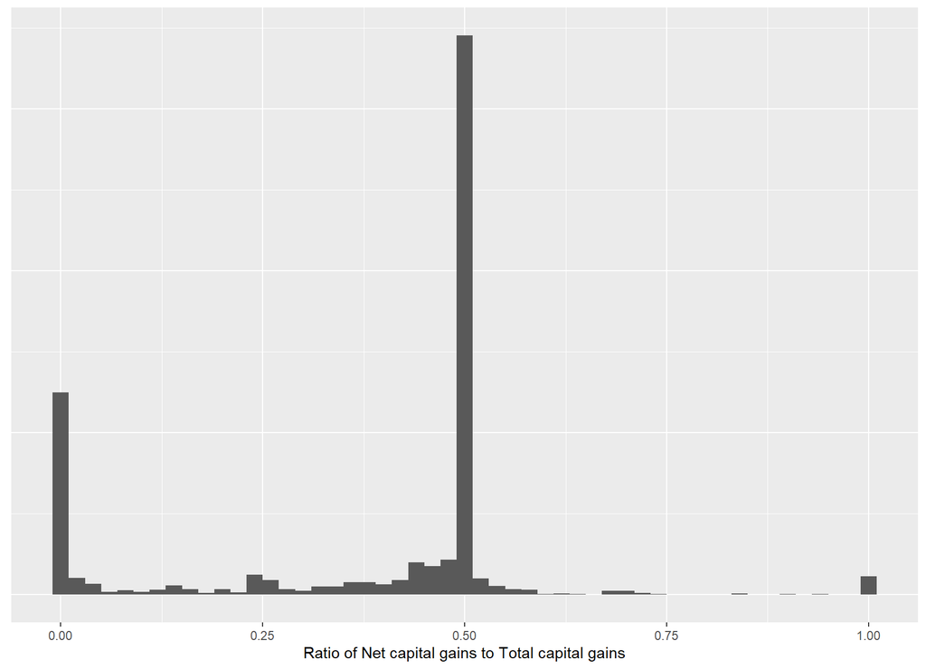

```r
sample_file %>%
  selector(Tot_CY_CG_amt, Net_CG_amt, WEIGHT) %>%
  .[Tot_CY_CG_amt > 0] %>%
  .[, apparent_discount := Net_CG_amt / Tot_CY_CG_amt] %>%
  .[, apparent_discount_round := round(apparent_discount * cgt_ratio_res) / cgt_ratio_res] %>%
  .[, keyby = .(apparent_discount_round),
    .(n_taxpayers = sum(WEIGHT),
      n_taxpayers_by_val = sum(as.double(WEIGHT * Tot_CY_CG_amt)))] %>%
  ggplot(aes(x = apparent_discount_round, y = n_taxpayers_by_val)) +
  xlab("Ratio of Net capital gains to Total capital gains") +
  geom_bar(stat = "identity", width = 1/cgt_ratio_res) +
  theme(axis.title.y = element_blank(),
        axis.ticks.y = element_blank(),
        axis.text.y = element_blank())
```

```r
CG_descriptive_by_bracket <-
  sample_file %>%
  copy %>%
  .[, tax := income_tax(Taxable_Income, fy.year = FY.YEAR)] %>%
  .[, tax_wo_CG := income_tax(pmax0(Taxable_Income - Net_CG_amt), fy.year = FY.YEAR)] %>%
  .[, .(n_taxpayers = sum(WEIGHT),
        n_CG = sum(WEIGHT[Net_CG_amt > 0]),
        val_CG = sum(as.double(Tot_CY_CG_amt * WEIGHT)),
        total_CGT = sum(as.double((tax - tax_wo_CG) * WEIGHT))),
    keyby = .(Tax_Bracket)]
```

```r
CG_descriptive_by_bracket %>%
  as.data.table %>%
  # cosmetic
  mutate(Taxpayers = comma(n_taxpayers),
         `with CG` = comma(n_CG),
         `Total cap. gains ($)` = grattan_dollar(val_CG),
         `Total CGT ($)` = grattan_dollar(total_CGT)) %>%
  select(`Tax bracket` = Tax_Bracket,
         `Taxpayers`, `with CG`, `Total cap. gains ($)`, `Total CGT ($)`) %>%
  kable(align = "rrrrrr")

```

[output not shown]

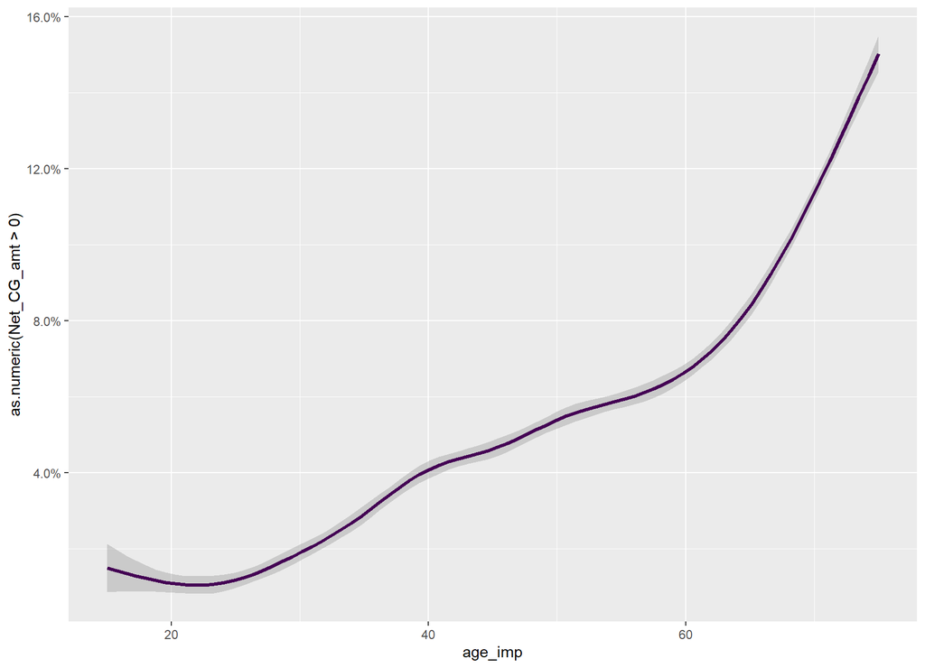

```r
sample_file %>%
  ggplot(aes(x = age_imp, y = as.numeric(Net_CG_amt > 0))) +
  geom_smooth(color = viridis(1), size = 1.2) +
  scale_y_continuous(label = percent)
```

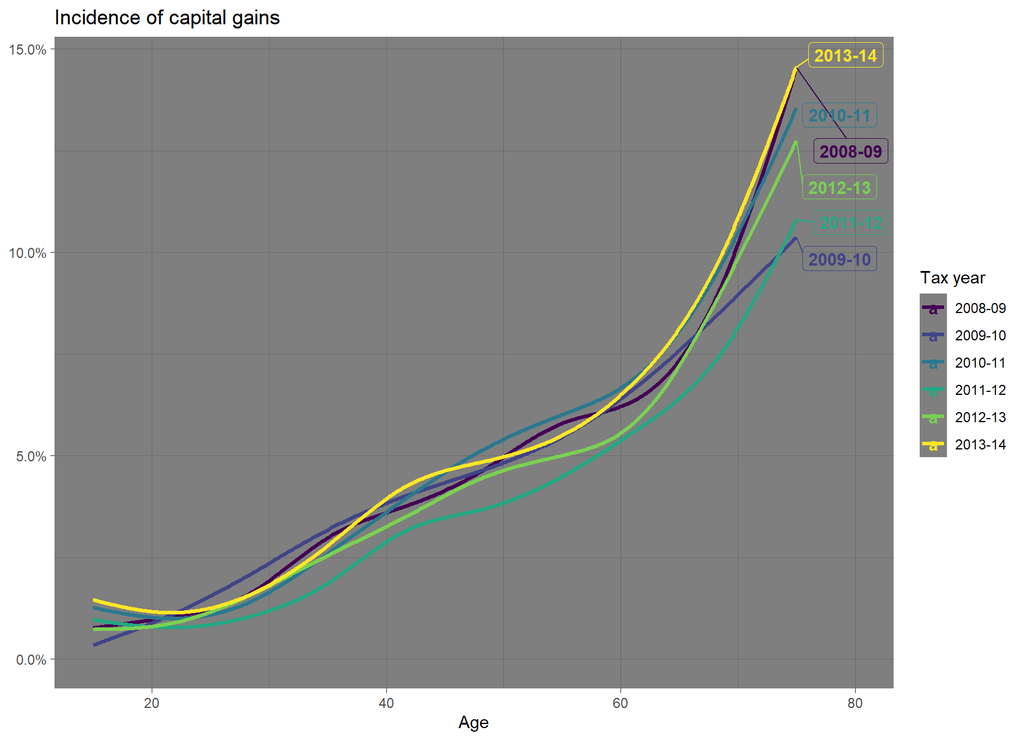

```r
# faster than ifelseing over the whole table
desc2min_age <- function(x) {
  if (grepl("to", x)) {
    sub("^([0-9]{2}).*$", "\\1", x)
  } else if (grepl("70", x)) {
    "70"
  } else {
    "15"
  }
}

sample_files_all %>%
  selector(age_range, Net_CG_amt, fy.year, shallow = TRUE) %>%
  merge(age_range_decoder, by = "age_range") %>%
  .[, min_age := desc2min_age(.BY[[1L]]),
    keyby = "age_range_description"] %>%
  .[, min_age := as.double(min_age)] %>%
  .[, max_age := min_age + 5] %>%
  .[, age_imp := rep_len(seq(from = .BY[["min_age"]],
                             to = .BY[["max_age"]],
                             # must be reasonably high to capture (infreq.)
                             # capital gains events
                             length.out = 2000),
                         .N),
    keyby = c("min_age", "max_age")] %>%
  unique(by = c("fy.year", "age_imp")) %>%
  .[, last_fy := fy.year == max(fy.year)] %>%
  .[, Tax_year := as.character(fy.year)] %>%
  .[, is_CG := as.double(Net_CG_amt > 0)] %>%
  .[, y := fitted(gam(is_CG ~ s(age_imp, bs = "cs"), data = .SD)), keyby = "Tax_year"] %>%
  .[, Age := round(age_imp, 1)] %>%
  .[, .(y = mean(y)), keyby = .(Tax_year, Age)] %>%
  .[, label := if_else(Age == max(Age), Tax_year, NA_character_), keyby = "Tax_year"] %>%
  .[] %>%
  ggplot(aes(x = Age,
             y = y,
             color = Tax_year,
             group = Tax_year)) +
  scale_y_continuous(label = percent) +
  ggtitle("Incidence of capital gains") +
  scale_color_viridis("Tax year", discrete = TRUE) +
  geom_line(size = 1.2) +
  # geom_line(stat = "smooth", method = "auto", se = FALSE, size = 1.2) +
  geom_label_repel(aes(label = label),
                   fill = NA,
                   nudge_x = 1,
                   xlim = c(75, NA),
                   hjust = 0,
                   vjust = 0,
                   fontface = "bold",
                   na.rm = TRUE) +
  geom_blank(aes(x = 80, y = 0)) +
  theme_dark() +
  theme(axis.title.y = element_blank())
```

```r
with_seed <- function(s, code) {
  if (requireNamespace("withr", quietly = TRUE)) {
    eval.parent(withr::with_seed(s, code))
  } else {
    code
  }
}
```

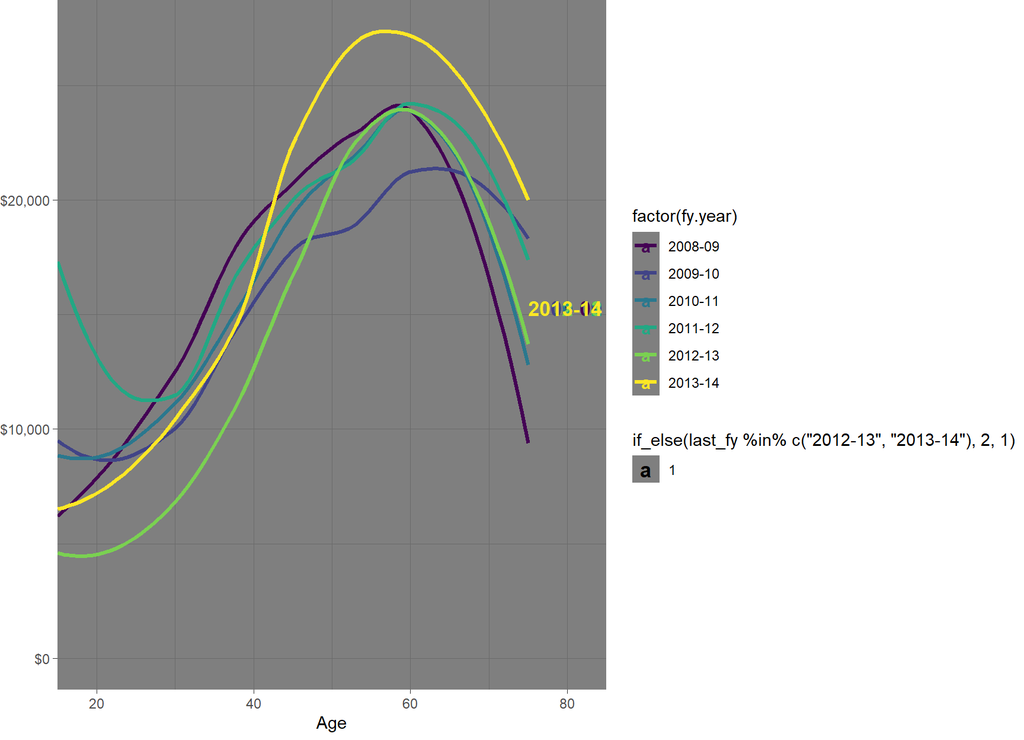

```r
with_seed(24841, {
  sample_files_all %>%
    .[, .(age_range, Net_CG_amt, fy.year)]%>%
    merge(age_range_decoder, by = "age_range") %>%
    .[,
      by = .(age_range_description),
      min_age :=
        if (grepl("^([0-9]{2}).*$", first(age_range_description))) {
          as.numeric(gsub("^([0-9]{2}).*$", "\\1", age_range_description))
        } else {
          if_else(grepl("70", age_range_description),
                  70,
                  15)
        }] %>%
    .[, max_age := min_age + 5] %>%
    .[, age_imp := runif(.N, min_age, max_age), by = .(age_range_description)]
}) %>%
  .[Net_CG_amt > 0] %>%
  .[, Age := round(age_imp)] %>%

  .[, .(mean_Net_CG = mean(Net_CG_amt),
        sd_Net_CG = sd(Net_CG_amt)),
    keyby = .(fy.year, Age)] %>%
  .[, last_fy := fy.year == max(fy.year) | fy.year == max(fy.year[fy.year != max(fy.year)])] %>%
  .[, label := fifelse(Age == max(Age), as.character(.BY[[1]]), NA_character_),
    keyby = .(fy.year)] %>%
  .[, label.y := mean(mean_Net_CG[Age > 70])] %>%
  {
    ggplot(., aes(x = Age, y = mean_Net_CG, color = factor(fy.year), group = factor(fy.year))) +
      scale_y_continuous(label = dollar) +
      scale_color_viridis(discrete = TRUE) +
      geom_line(stat = "smooth", method = "auto", se = FALSE, size = 1.2) +
      scale_alpha_discrete(range = c(0.5, 1)) +
      geom_text(aes(label = label, y = label.y, size = if_else(last_fy %in% c("2012-13", "2013-14"), 2, 1),
                    nudge_x = if_else(last_fy, 1, 0)),
                hjust = 0,
                vjust = 0,
                fontface = "bold",
                na.rm = TRUE) +
      scale_x_continuous(expand = c(0,0)) +
      theme_dark() +
      annotate("blank",
               x = 85, y = 0) +
      theme(axis.title.y = element_blank(),
            plot.margin = unit(c(0,0,5,0), "pt"))
  }
```

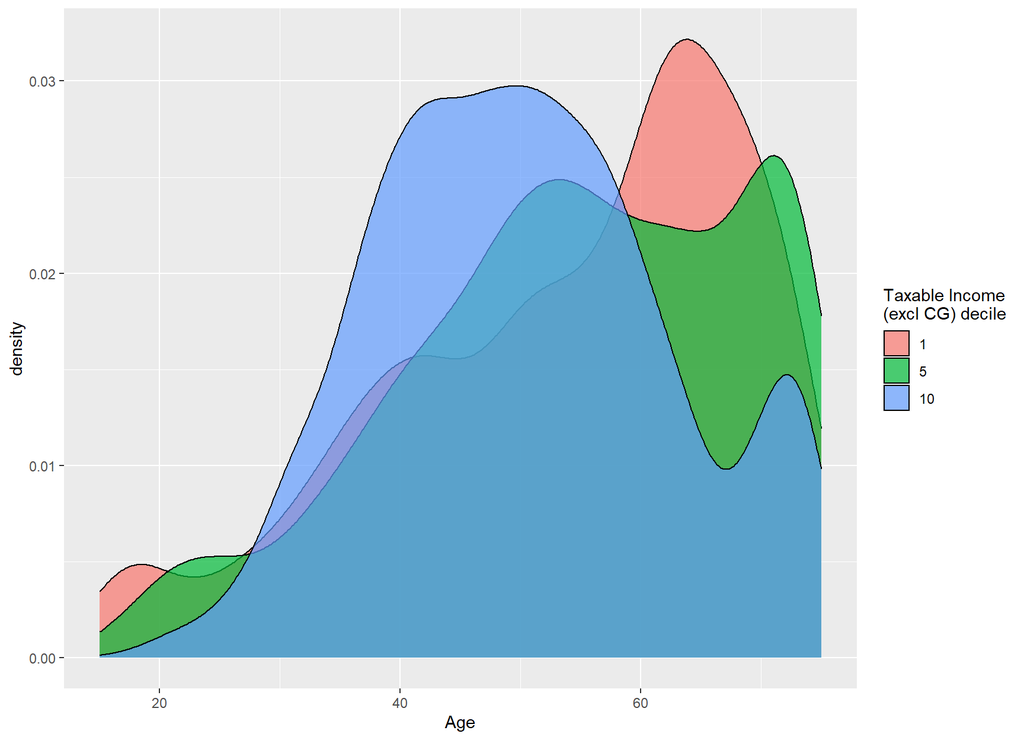

```r
sample_file %>%
  mutate(Tot_inc_amt_noCG = Tot_inc_amt - Net_CG_amt,
         Taxable_Income_noCG = pmaxC(Tot_inc_amt_noCG - Tot_ded_amt - NPP_loss_claimed - PP_loss_claimed, 0)) %>%
  mutate(Taxable_Income_noCG_decile = ntile(Taxable_Income_noCG, 10)) %>%
  filter(Taxable_Income_noCG_decile %in% c(1, 5, 10)) %>%
  filter(Net_CG_amt > 0) %>%
  rename(Age = age_imp) %>%
  mutate(`Taxable Income\n(excl CG) decile` = factor(Taxable_Income_noCG_decile)) %>%
  ggplot(aes(x = Age, fill = `Taxable Income\n(excl CG) decile`)) +
  geom_density(alpha = 0.7) +
  theme(legend.position = "right")





```

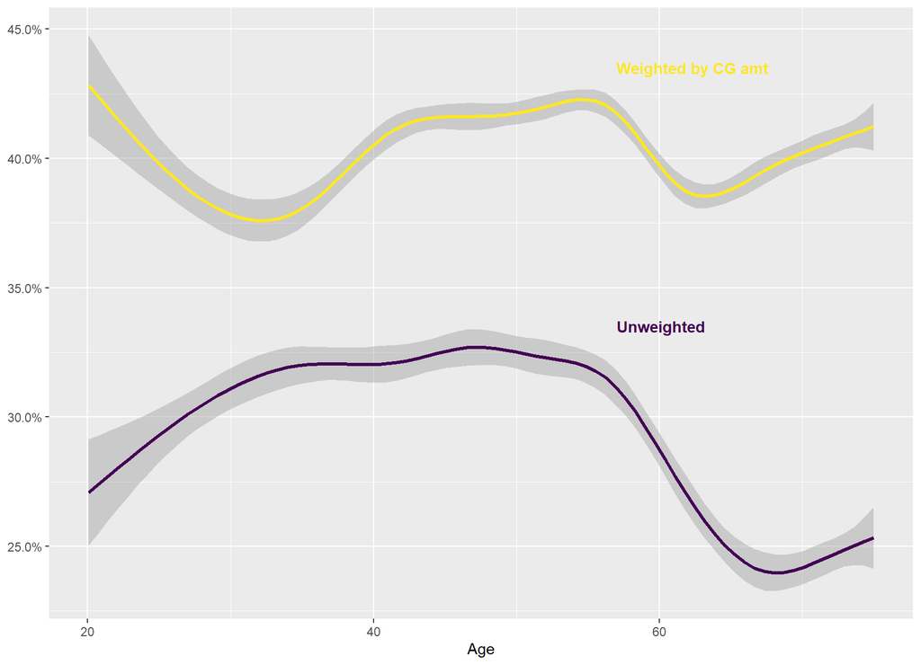

```r
if (FY.YEAR != "2013-14"){
  stop("Check annotations in this chart before compiling")
}
sample_file %>%
  .[Net_CG_amt > 0 & age_imp > 20] %>%
  .[, marginal_rate := income_tax(Taxable_Income + 1, fy.year = FY.YEAR) - income_tax(Taxable_Income, fy.year = FY.YEAR)] %>%
  setnames("age_imp", "Age") %>%
  as.data.frame %>%
  ggplot(aes(x = Age, y = marginal_rate)) +
  scale_y_continuous(label = percent) +
  geom_smooth(aes(weight = 1), colour = viridis(2)[1], size = 1.2) +
  geom_smooth(aes(weight = Net_CG_amt), colour = viridis(2)[2], size = 1.2) +
  annotate("text",
           x = c(57, 57),
           y = c(0.335, 0.435),
           label = c("Unweighted", "Weighted by CG amt"),
           colour = viridis(2),
           fontface = "bold",
           hjust = 0) +
  theme(axis.title.y = element_blank())
```

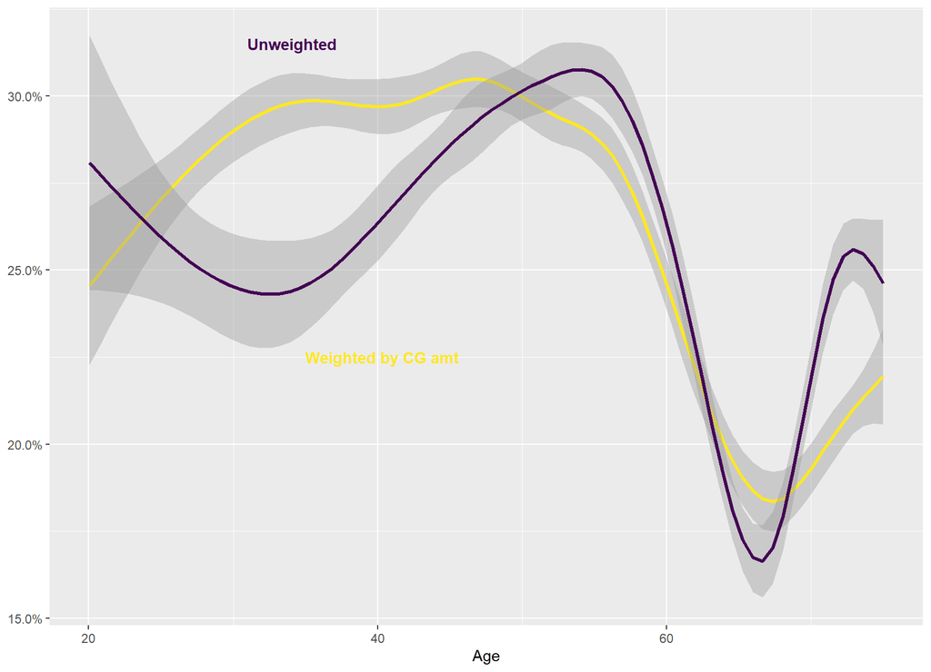

```r
if (FY.YEAR != "2013-14"){
  stop("Check annotations in this chart before compiling")
}
sample_file %>%
  .[Net_CG_amt > 0 & age_imp > 20] %>%
  .[, Taxable_Income_b4_CG := pmaxC(Taxable_Income - Net_CG_amt, 0)] %>%
  .[, marginal_rate_b4_CG := income_tax(Taxable_Income_b4_CG + 1, fy.year = FY.YEAR) - income_tax(Taxable_Income_b4_CG, fy.year = FY.YEAR)] %>%
  setnames("age_imp", "Age") %>%
  as.data.frame %>%
  ggplot(aes(x = Age, y = marginal_rate_b4_CG)) +
  scale_y_continuous(label = percent) +
  geom_smooth(aes(weight = 1),  colour = viridis(2)[2], size = 1.2) +
  geom_smooth(aes(weight = Net_CG_amt), colour = viridis(2)[1], size = 1.2) +
  annotate("text",
           x = c(31, 35),
           y = c(0.315, 0.225),
           label = c("Unweighted", "Weighted by CG amt"),
           colour = viridis(2),
           fontface = "bold",
           hjust = 0) +
  theme(axis.title.y = element_blank())
```

```r
n_prop_invstrs <-
  sample_file %$%
  sum((Gross_rent_amt > 0) * WEIGHT)

n_NGs <-
  sample_file %$%
  sum((Net_rent_amt < 0) * WEIGHT)

val_NG_losses <-
  sample_file %$%
  sum(abs(pminC(Net_rent_amt, 0) * WEIGHT))

NG_tax_exp <-
  sample_file %>%
  mutate(tax = income_tax(Taxable_Income, fy.year = FY.YEAR),
         new_tax = income_tax(Taxable_Income - pminC(Net_rent_amt, 0), fy.year = FY.YEAR),
         diff = new_tax - tax) %$%
  sum(diff * WEIGHT)
```

There were 2~million property investors. Of these, 1.25~million were negative gearing. Losses claimed totaled $10.7~billion. This delivered a tax expenditure (by revenue foregone) of $3.63~billion.

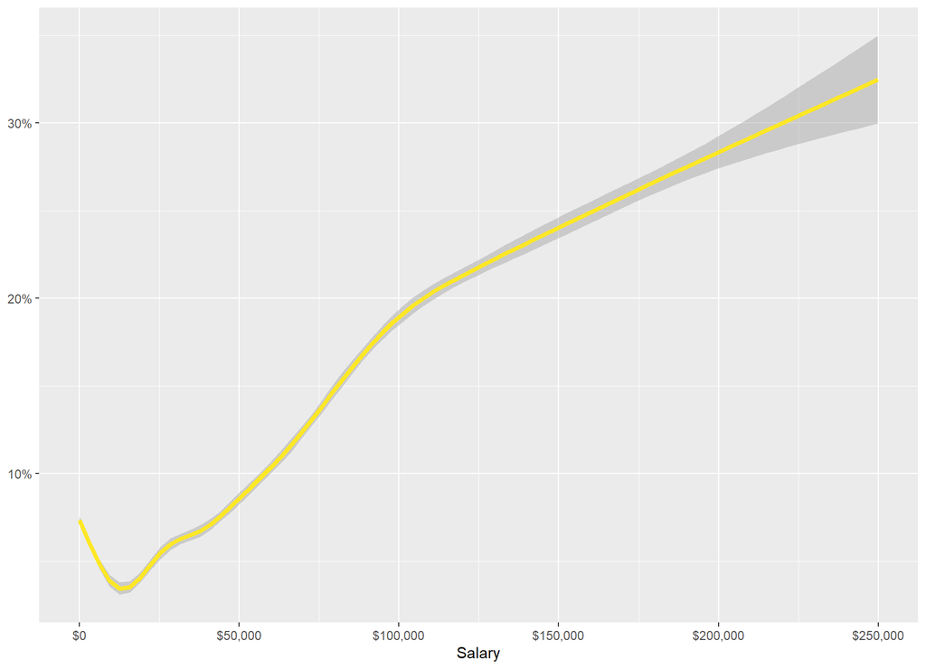

```r
sample_file %>%
  filter(between(Sw_amt, 0, 250e3)) %>%
  rename(Salary = Sw_amt) %>%
  ggplot(aes(x = Salary, y = as.numeric(Net_rent_amt < 0))) +
  geom_smooth(colour = viridis(2)[2], size = 1.5) +
  scale_y_continuous(label = percent) +
  scale_x_continuous(label = dollar) +
  theme(axis.title.y = element_blank())

```

```r
NG_by_taxBracket <-
  sample_file %>%
  mutate(Tax_bracket = cut(Taxable_Income,
                             breaks = c(-Inf, 18200, 37e3, 80e3, 180e3, Inf),
                             labels = c("$0-$18,200", "$18,201-$37,000",
                                        "$37,001-$80,000", "$80,001-$180,000",
                                        "Over $180,000"),
                             ordered_results = TRUE,
                             include.lowest = TRUE)) %>%
  group_by(Tax_bracket) %>%
  summarise(n_NG = wsum(Net_rent_amt < 0, WEIGHT),
            n = sum(WEIGHT)) %>%
  arrange(Tax_bracket)

NG_by_taxBracket %>%
  mutate(`Number negative gearing` = comma(n_NG),
         `\\%` = percent(n_NG / n)) %>%
  select(`Tax bracket` = Tax_bracket,
         `Number negative gearing`,
         `\\%`) %>%
  kable(align = "rrr")
```

| Tax bracket | Number negative gearing | % |
| --- | --- | --- |
| $0-$18,200 | 161,800 | 6.44% |
| $18,201-$37,000 | 180,950 | 5.83% |
| $37,001-$80,000 | 469,500 | 9.76% |
| $80,001-$180,000 | 350,800 | 16.43% |
| Over $180,000 | 85,200 | 22.42% |

```r
NG_by_taxBracket_tax_benefit <-
  sample_file %>%
  mutate(Tot_inc_amt_NoNG = Tot_inc_amt - Net_rent_amt + pmaxC(Net_rent_amt, 0),
         Taxable_Income_noNG = pmaxC(Tot_inc_amt_NoNG - Tot_ded_amt - NPP_loss_claimed - PP_loss_claimed, 0),
         tax_current = income_tax(Taxable_Income, fy.year = FY.YEAR),
         tax_noNG = income_tax(Taxable_Income_noNG, fy.year = FY.YEAR),
         change = tax_noNG - tax_current) %>%
  mutate(Tax_bracket = cut(Taxable_Income,
                             breaks = c(-Inf, 18200, 37e3, 80e3, 180e3, Inf),
                             labels = c("$0-$18,200",
                                        "$18,201-$37,000",
                                        "$37,001-$80,000",
                                        "$80,001-$180,000",
                                        "Over $180,000"),
                             ordered_results = TRUE,
                             include.lowest = TRUE)) %>%
  group_by(Tax_bracket) %>%
  summarise(total_tax_change = sum(change * WEIGHT),
            avg_tax_change = mean(change)) %>%
  arrange(Tax_bracket)


NG_by_taxBracket_tax_benefit %>%
  mutate(`Total tax change` = grattan_dollar(total_tax_change),
         `Average tax change` = grattan_dollar(avg_tax_change)) %>%
  select(`Tax bracket` = Tax_bracket,
         `Total tax change`,
         `Average tax change`) %>%
  kable(align = paste0(rep("r", ncol(.)), collapse = ""))
```

| Tax bracket | Total tax change | Average tax change |
| --- | --- | --- |
| $0-$18,200 | $97,261,913 | $39 |
| $18,201-$37,000 | $333,873,994 | $108 |
| $37,001-$80,000 | $1,246,976,877 | $259 |
| $80,001-$180,000 | $1,288,682,051 | $603 |
| Over $180,000 | $648,280,796 | $1,706 |

```r
NG_by_taxable_income_decile <-
  sample_file %>%
  mutate(Taxable_Income_decile = ntile(Taxable_Income, 10)) %>%
  group_by(Taxable_Income_decile) %>%
  summarise(n_NG = wsum(Net_rent_amt < 0, WEIGHT),
            n = sum(WEIGHT)) %>%
  arrange(Taxable_Income_decile)

NG_by_taxable_income_decile %>%
mutate(`Number negative gearing` = comma(n_NG),
         `\\%` = percent(n_NG / n)) %>%
  mutate(`Taxable Income decile` = factor(Taxable_Income_decile)) %>%
  select(`Taxable Income decile`,
         `Number negative gearing`,
         `\\%`) %>%
  kable(align = "rrrr")
```

| Taxable Income decile | Number negative gearing | % |
| --- | --- | --- |
| 1 | 109,550 | 8.47% |
| 2 | 55,750 | 4.31% |
| 3 | 64,950 | 5.02% |
| 4 | 82,400 | 6.37% |
| 5 | 93,750 | 7.25% |
| 6 | 106,550 | 8.24% |
| 7 | 130,750 | 10.11% |
| 8 | 157,950 | 12.21% |
| 9 | 192,600 | 14.89% |
| 10 | 254,000 | 19.63% |

```r
NG_tax_benefit_taxable_income_decile <-
  sample_file %>%
  mutate(Tot_inc_amt_NoNG = Tot_inc_amt - Net_rent_amt + pmaxC(Net_rent_amt, 0),
         Taxable_Income_noNG = pmaxC(Tot_inc_amt_NoNG - Tot_ded_amt - NPP_loss_claimed - PP_loss_claimed, 0),
         tax_current = income_tax(Taxable_Income, fy.year = FY.YEAR),
         tax_noNG = income_tax(Taxable_Income_noNG, fy.year = FY.YEAR),
         change = tax_noNG - tax_current) %>%
  mutate(Taxable_Income_decile = ntile(Taxable_Income, 10)) %>%
  group_by(Taxable_Income_decile) %>%
  summarise(tax_diff = sum(change * WEIGHT)) %>%
  ungroup %>%
  mutate(tax_diff_prop = tax_diff / sum(tax_diff)) %>%
  arrange(Taxable_Income_decile) %>%
  mutate(decile_by = "Taxable income")


NG_tax_benefit_taxable_income_decile_noNG <-
  sample_file %>%
  mutate(Tot_inc_amt_NoNG = Tot_inc_amt - Net_rent_amt + pmaxC(Net_rent_amt, 0),
         Taxable_Income_noNG = pmaxC(Tot_inc_amt_NoNG - Tot_ded_amt - NPP_loss_claimed - PP_loss_claimed, 0),
         tax_current = income_tax(Taxable_Income, fy.year = FY.YEAR),
         tax_noNG = income_tax(Taxable_Income_noNG, fy.year = FY.YEAR),
         change = tax_noNG - tax_current) %>%
  mutate(Taxable_Income_decile = ntile(Taxable_Income_noNG, 10)) %>%
  group_by(Taxable_Income_decile) %>%
  summarise(tax_diff = sum(change * WEIGHT)) %>%
  ungroup %>%
  mutate(tax_diff_prop = tax_diff / sum(tax_diff)) %>%
  arrange(Taxable_Income_decile) %>%
  mutate(decile_by = "Taxable income before NG")


```

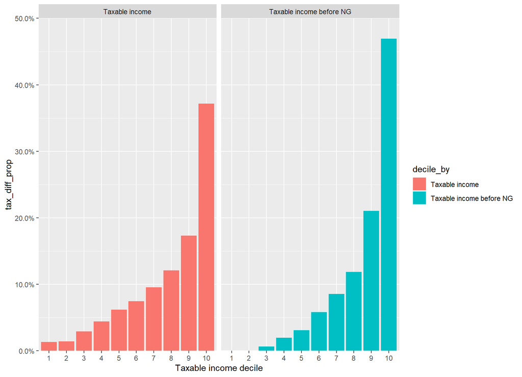

```r
bind_rows("Current" = NG_tax_benefit_taxable_income_decile,
          "Before NG" = NG_tax_benefit_taxable_income_decile_noNG) %>%
  mutate(`Taxable income decile` = factor(Taxable_Income_decile)) %>%
  ggplot(aes(x = `Taxable income decile`, y = tax_diff_prop, fill = decile_by)) +
  geom_bar(stat = "identity") +
  facet_grid(~decile_by) +
  scale_y_continuous(label = percent,
                     expand = c(0,0),
                     limits = c(0, round(max(c(NG_tax_benefit_taxable_income_decile_noNG$tax_diff_prop,
                                               NG_tax_benefit_taxable_income_decile$tax_diff_prop)), 1)))
```

```r
NG_tax_benefit_taxable_income_decile_prev <-
  sample_file_prev %>%
  mutate(Tot_inc_amt_NoNG = Tot_inc_amt - Net_rent_amt + pmaxC(Net_rent_amt, 0),
         Taxable_Income_noNG = pmaxC(Tot_inc_amt_NoNG - Tot_ded_amt - NPP_loss_claimed - PP_loss_claimed, 0),
         tax_current = income_tax(Taxable_Income, fy.year = FY.YEAR),
         tax_noNG = income_tax(Taxable_Income_noNG, fy.year = FY.YEAR),
         change = tax_noNG - tax_current) %>%
  mutate(Taxable_Income_decile = ntile(Taxable_Income, 10)) %>%
  group_by(Taxable_Income_decile) %>%
  summarise(tax_diff = sum(change * WEIGHT)) %>%
  ungroup %>%
  mutate(tax_diff_prop = tax_diff / sum(tax_diff)) %>%
  arrange(Taxable_Income_decile) %>%
  mutate(decile_by = "Taxable income")


NG_tax_benefit_taxable_income_decile_noNG_prev <-
  sample_file_prev %>%
  mutate(Tot_inc_amt_NoNG = Tot_inc_amt - Net_rent_amt + pmaxC(Net_rent_amt, 0),
         Taxable_Income_noNG = pmaxC(Tot_inc_amt_NoNG - Tot_ded_amt - NPP_loss_claimed - PP_loss_claimed, 0),
         tax_current = income_tax(Taxable_Income, fy.year = FY.YEAR),
         tax_noNG = income_tax(Taxable_Income_noNG, fy.year = FY.YEAR),
         change = tax_noNG - tax_current) %>%
  mutate(Taxable_Income_decile = ntile(Taxable_Income, 10)) %>%
  group_by(Taxable_Income_decile) %>%  summarise(tax_diff = sum(change * WEIGHT)) %>%
  ungroup %>%
  mutate(tax_diff_prop = tax_diff / sum(tax_diff)) %>%
  arrange(Taxable_Income_decile) %>%
  mutate(decile_by = "Taxable income before NG")


```

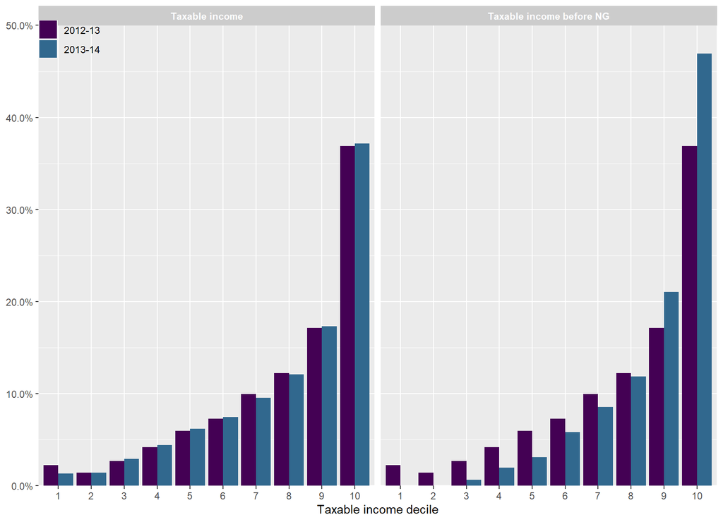

```r
bind_rows("Current" = NG_tax_benefit_taxable_income_decile,
          "Before NG" = NG_tax_benefit_taxable_income_decile_noNG,
          "Current (prev fy)" = NG_tax_benefit_taxable_income_decile_prev,
          "Before NG (prev fy)" = NG_tax_benefit_taxable_income_decile_noNG_prev,
          .id = "df_id") %>%
  mutate(`Taxable income decile` = factor(Taxable_Income_decile)) %>%
  mutate(financial_year = ifelse(grepl("prev fy", df_id), PREV.FY.YEAR, FY.YEAR)) %>%
  ggplot(aes(x = `Taxable income decile`, y = tax_diff_prop, fill = financial_year)) +
  geom_bar(stat = "identity", position = "dodge") +
  scale_fill_viridis(discrete = TRUE, begin = 0, end = 0.3333) +
  facet_grid(~decile_by) +
  scale_y_continuous(label = percent,
                     expand = c(0,0),
                     limits = c(0, round(max(c(NG_tax_benefit_taxable_income_decile_noNG$tax_diff_prop,
                                               NG_tax_benefit_taxable_income_decile$tax_diff_prop)), 1))) +
  theme(legend.margin = unit(0, "lines"),
        legend.title = element_blank(),
        legend.position = c(0.00, 1.025),
        legend.background = element_blank(),

        legend.justification = c(0, 1),
        axis.title.y = element_blank(),
        strip.background = element_rect(color = grey(0.8), fill = grey(0.8)),
        strip.text = element_text(colour = "white", face = "bold"))
```

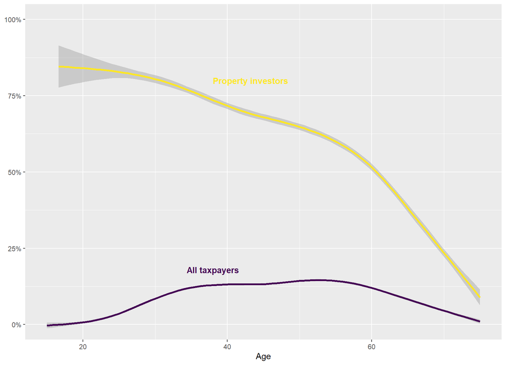

```r
p <-
  ggplot(NULL) +
  geom_smooth(data = sample_file,
              aes(x = age_imp, y = as.numeric(Net_rent_amt < 0)),
              colour = viridis(2)[1],
              size = 1.2) +
  geom_smooth(data = filter(sample_file, Gross_rent_amt > 0),
              aes(x = age_imp,
                  y = as.numeric(Net_rent_amt < 0)),
              colour = viridis(2)[2],
              size = 1.2) +
  scale_y_continuous(label = percent) +
  xlab("Age") +
  coord_cartesian(ylim = c(0,1)) +
  theme(axis.title.y = element_blank())
if (FY.YEAR == "2013-14"){
  p <-
    p +
    annotate("text",
             x = c(38, 38),
             y = c(0.18, y = 0.80),
             label = c("All taxpayers", "Property investors"),
             hjust = c(0.5, 0),
             colour = viridis(2),
             fontface = "bold")
} else {
  p <- p +
    theme(legend.position = "right")
}

p
```

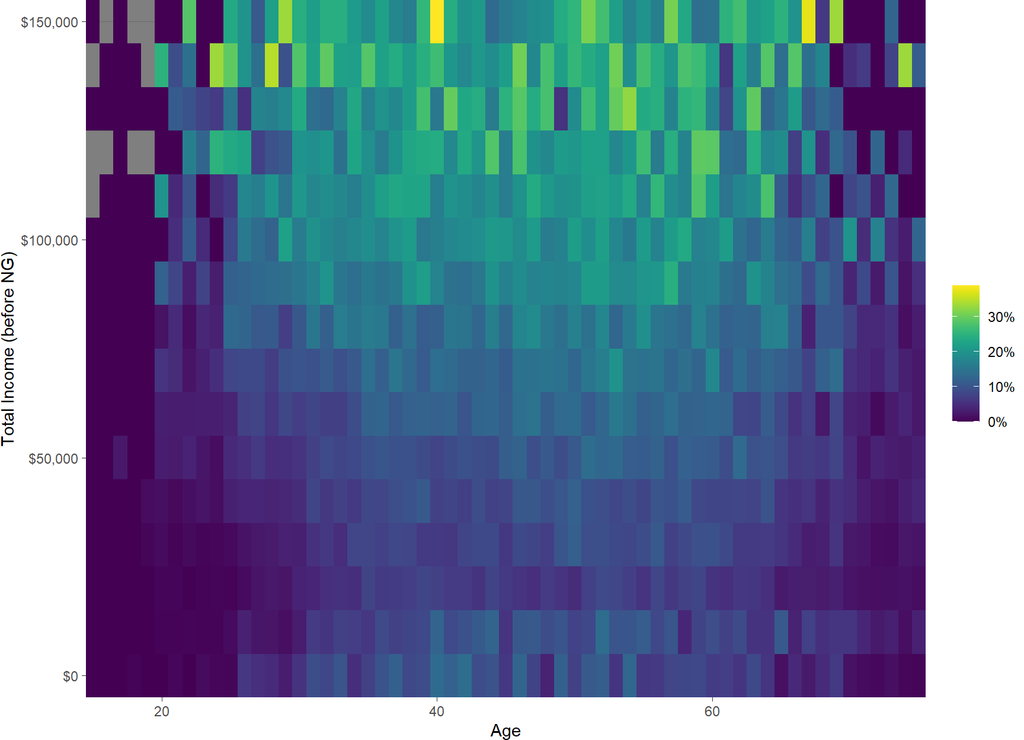

```r
age_res = 1
inc_res = 10000

sample_file %>%
  mutate(Tot_inc_amt_NoNG = Tot_inc_amt - Net_rent_amt + pmaxC(Net_rent_amt, 0),
         Taxable_Income_noNG = pmaxC(Tot_inc_amt_NoNG - Tot_ded_amt - NPP_loss_claimed - PP_loss_claimed, 0),
         tax_current = income_tax(Taxable_Income, fy.year = FY.YEAR),
         tax_noNG = income_tax(Taxable_Income_noNG, fy.year = FY.YEAR),
         change = tax_noNG - tax_current) %>%

  # This excludes income losses (barely any anyway)
  # and high income earners
  filter(between(Tot_inc_amt_NoNG,
                 0,
                 upper_ylim <<- quantile(.$Tot_inc_amt_NoNG[.$Tot_inc_amt_NoNG > 0], probs = 0.95))) %>%

  mutate(Age = age_res * round(age_imp / age_res),
         `Total Income (before NG)` = inc_res * round(Tot_inc_amt_NoNG / inc_res)) %>%
  group_by(Age, `Total Income (before NG)`) %>%
  summarise(n_NG = sum((Net_rent_amt < 0) * WEIGHT),
            prop_NG = mean(Net_rent_amt < 0),
            tot_tax_benefit = sum(change * WEIGHT),
            avg_tax_benefit = mean(change)) %>% ungroup %>%


  ggplot(aes(x = Age, y = `Total Income (before NG)`, fill = prop_NG)) +
  geom_bin2d(stat = "identity") +
  scale_fill_viridis("% NG", labels = percent) +
  scale_y_continuous(expand = c(0,0), label = grattan_dollar) +
  scale_x_continuous(expand = c(0,0)) +
  theme_dark() +
  theme(legend.title = element_blank(),
        plot.margin = unit(c(0,0,0,0), "pt"))# %>%



```

```r
  #align_baptiste(.)
```

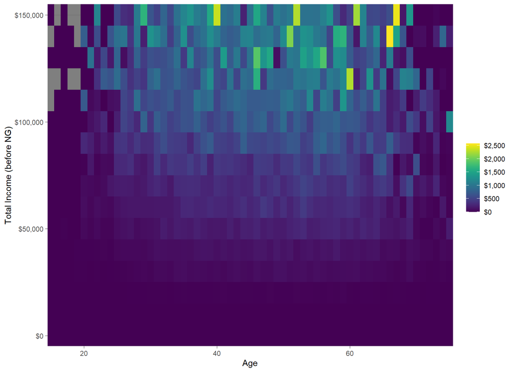

```r
age_res = 1
inc_res = 10000

sample_file %>%
  mutate(Tot_inc_amt_NoNG = Tot_inc_amt - Net_rent_amt + pmaxC(Net_rent_amt, 0),
         Taxable_Income_noNG = pmaxC(Tot_inc_amt_NoNG - Tot_ded_amt - NPP_loss_claimed - PP_loss_claimed, 0),
         tax_current = income_tax(Taxable_Income, fy.year = FY.YEAR),
         tax_noNG = income_tax(Taxable_Income_noNG, fy.year = FY.YEAR),
         change = tax_noNG - tax_current) %>%

  # This excludes income losses (barely any anyway)
  # and high income earners
  filter(between(Tot_inc_amt_NoNG,
                 0,
                 upper_ylim <<- quantile(.$Tot_inc_amt_NoNG[.$Tot_inc_amt_NoNG > 0], probs = 0.95))) %>%

  mutate(Age = age_res * round(age_imp / age_res),
         `Total Income (before NG)` = inc_res * round(Tot_inc_amt_NoNG / inc_res)) %>%
  group_by(Age, `Total Income (before NG)`) %>%
  summarise(n_NG = sum((Net_rent_amt < 0) * WEIGHT),
            prop_NG = mean(Net_rent_amt < 0),
            tot_tax_benefit = sum(change * WEIGHT),
            avg_tax_benefit = mean(change)) %>% ungroup %>%


  ggplot(aes(x = Age, y = `Total Income (before NG)`, fill = avg_tax_benefit)) +
  geom_bin2d(stat = "identity") +
  scale_fill_viridis("Tax benefit", labels = grattan_dollar) +
  scale_y_continuous(expand = c(0,0), label = grattan_dollar) +
  scale_x_continuous(expand = c(0,0)) +
  theme_dark() +
  theme(legend.title = element_blank())



```

# Differential uprating

Since the most recent versions of data detailing population income and wealth (as is contained within the ATO’s sample files) is typically years out-of-date on release, even understanding the present requires a forecast. Since most variables relating to income increase due to inflation – so any sensible forecast will increase the values relative to the past – this procedure is often called **uprating**.

## Basic uprating

The most basic uprate method is the identity function, where the variables are not changed.

Alternatively, the variables can be increased by a long-term inflation rate. Even better, we can use the relevant time series indices for the variables and inflate using that index. For instance, salary and wage variables can be increased by the observed increase in the wage price index amd growth in the population of taxpayers by the labour force index.

## Differential uprating

Basic uprating suffers some limitations. There are significant structural differences in how much individuals’ incomes grow. High-income individuals tend to have higher than average wage growth. Low-income individuals also have higher than average wage growth. That is, the pattern of wage growth by wage is U-shaped.

```r
wage_r_by_fy <-
  data.table(fy.year = yr2fy(2005:2014)) %>%
  mutate(lag_fy = yr2fy(2004:2013)) %>%
  mutate(wage_growth_r = wage_inflator(from_fy = lag_fy, to_fy = fy.year) - 1)

average_salary_by_fy_swtile <-
  sample_files_all %>%
  select(fy.year, Sw_amt) %>%
  filter(Sw_amt > 0) %>%
  group_by(fy.year) %>%
  mutate(`Salary percentile` = ntile(Sw_amt, 100)) %>%
  ungroup %>%
  group_by(fy.year, `Salary percentile`) %>%
  summarise(average_salary = mean(Sw_amt)) %>%
  ungroup %>%
  arrange(`Salary percentile`, fy.year) %>%
  group_by(`Salary percentile`) %>%
  mutate(r_average_salary = average_salary / lag(average_salary) - 1) %>%
  filter(fy.year != min(fy.year))


```

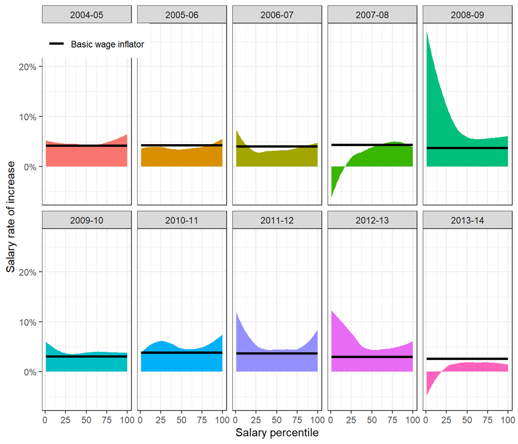

```r
{
  p <-
    average_salary_by_fy_swtile %>%  # NA
    ungroup %>%
    merge(wage_r_by_fy, by = "fy.year") %>%
    mutate(`Basic wage inflator` = "Basic wage inflator") %>%
    ggplot() +
    geom_area(aes(x = `Salary percentile`, y = r_average_salary, group = fy.year, fill = fy.year),
              se = FALSE, stat = "smooth", method = "loess") +
    theme_bw() +
    theme(legend.position = "right", plot.background = element_blank()) +
    geom_line(aes(x = `Salary percentile`, y = wage_growth_r, group = `Basic wage inflator`, color = `Basic wage inflator`),
              size = 1.125) +
    scale_color_manual(values = "black") +
    scale_y_continuous(name = "Salary rate of increase", label = percent) +
    facet_wrap(~fy.year, ncol = 5) +
    guides(fill = FALSE) +
    theme(legend.position = c(0, 1),
          legend.title = element_blank(),
          legend.key = element_blank(),
          legend.justification = c(0, 1))

  # ggplotly(p)
  p
}
```

```r
differential_uprates <-
  average_salary_by_fy_swtile %>%
  group_by(`Salary percentile`) %>%
  summarise(avg_r = mean(r_average_salary)) %>%
  mutate(avg_r_normed = avg_r / mean(avg_r))
```

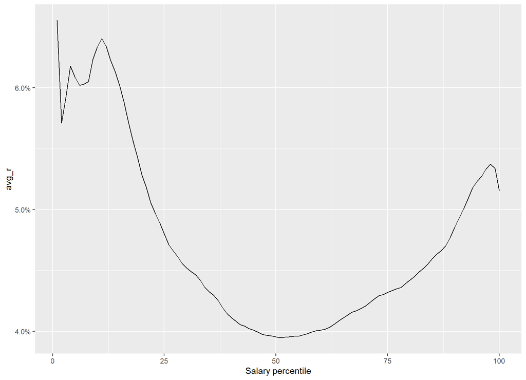

```r
differential_uprates %>%
  ggplot(aes(x = `Salary percentile`, y = avg_r)) +
  geom_line() +
  scale_y_continuous(label = percent)
```

**Differential uprating** is a method by which variables are uprated by a function of not only the time period and the type of variable, but of the variable’s value too. To differentially uprate salary, use `differentially_uprate_wage`:

```r
data.table(wage = c(20e3, 50e3, 100e3)) %>%
  mutate(ordinary = wage_inflator(wage, from_fy = "2012-13", to_fy = "2013-14"),
         `change ordinary` = ordinary / wage - 1,
         differential = differentially_uprate_wage(wage, from_fy = "2012-13", to_fy = "2013-14"),
         `change differential` = differential / wage - 1
         ) %>%
  mutate(wage = dollar(wage),
         ordinary = dollar(ordinary),
         differential = dollar(differential),
         `change ordinary` = percent(`change ordinary`),
         `change differential` = percent(`change differential`)) %>%
  kable(align = rep("r", ncol(.)))

```

| wage | ordinary | change ordinary | differential | change differential |
| --- | --- | --- | --- | --- |
| $20,000 | $20,519.48 | 3% | $20,545.69 | 2.728% |
| $50,000 | $51,298.7 | 3% | $51,157.53 | 2.315% |
| $100,000 | $102,597.4 | 3% | $102,652.3 | 2.652% |

Note that `differentially_update_wage` uses the 2003-04 to 2013-14 sample files to generate estimates of the shape of the U. So applying the function to any other vector may have surprising results. In particular, the distribution of the vector provided is not considered. Furthermore, the `from_fy` must be in the range `2003-04` to `2013-14`.

# Modelling superannuation changes

## Introduction

Australia’s superannuation system offers a number of tax breaks. Relative to most methods of savings, less tax is paid on money contributed to a super fund, and less tax is paid on the earnings. The functions described here attempt to model changes to tax breaks on money contributed to a super fund.

## Modelling

### The basic functions

The two tax methods modelled are **Superannuation contributions tax concessions** and **Division 293 tax**. The two main outputs are: the extra tax payable by a particular individual (and the symmetric extra revenue), and the number of individuals affected.

To obtain these results (say for 2017-18)

```r
library(grattan)
library(data.table)
library(magrittr)
#' dollar scales
#'
#' @name grattan_dollar
#' @param x A numeric vector
#' @param digits Minimum number of digits after the decimal point. (\code{nsmall} in \code{base::format}).
#' @details Makes negative numbers appear as \eqn{-\$10,000} instead of \eqn{\$-10,000} in \code{scales::dollar}.
#' @export
# from scales

grattan_dollar <- function (x, digits = 0) {
  #
  nsmall <- digits
  commaz <- format(abs(x), nsmall = nsmall, trim = TRUE, big.mark = ",",
                   scientific = FALSE, digits = 1L)

  hutils::if_else(x < 0,
          paste0("\U2212","$", commaz),
          paste0("$", commaz))
}

(new_revenue <-
  sample_file_1314 %>%
  project_to(to_fy = "2017-18") %>%
  as.data.table %>%
  revenue_from_new_cap_and_div293(new_cap = 25e3, fy.year = "2016-17", new_age_based_cap = FALSE, new_div293_threshold = 250e3))
```

```
#> [1] 687135123
```

```r
paste(grattan_dollar(new_revenue / 1e9), "bn")
```

```
#> [1] "$0.7 bn"
```

```r
(n_affected <-
  sample_file_1314 %>%
  project_to(to_fy = "2017-18") %>%
  as.data.table %>%
  n_affected_from_new_cap_and_div293(new_cap = 25e3, fy.year = "2016-17", new_age_based_cap = FALSE, new_div293_threshold = 250e3))
```

```
#> [1] 550729.1
```

```r
prettyNum(round(n_affected), big.mark = ",")
```

```
#> [1] "550,729"
```

### Distributional analysis

#### By taxable income decile

Let’s create an object for `sample_file_1718` avoid recreating it every time:

```r
sample_file_1718 <-
  sample_file_1314 %>%
  project_to(to_fy = "2017-18") %>%
  as.data.table
```

The functions mentioned earlier return single values. In contrast, `model_new_caps_and_div293` returns the sample file with extra variables, which can then be analyzed as a standard sample file. The variables of note are `prv_revenue` which is the tax payable under the old system, and `new_revenue` which is the tax payable under the proposed system. Thus:

```r
new_sample_file_1718 <-
  sample_file_1718 %>%
  model_new_caps_and_div293(new_cap = 25e3, fy.year = "2016-17", new_age_based_cap = FALSE, new_div293_threshold = 250e3)
```

```r
library(knitr)
library(dplyr)
library(dtplyr)  # for data.table

new_sample_file_1718 %>%
  mutate(Taxable_Income_decile = ntile(Taxable_Income, 10)) %>%
  group_by(Taxable_Income_decile) %>%
  summarise(`Average increase in tax` = round(mean(new_revenue - prv_revenue), 2)) %>%
  arrange(Taxable_Income_decile) %>%
  kable

```

| Taxable_Income_decile | Average increase in tax |
| --- | --- |
| 1 | -4.45 |
| 2 | -0.80 |
| 3 | 4.40 |
| 4 | 14.91 |
| 5 | 16.72 |
| 6 | 20.83 |
| 7 | 25.75 |
| 8 | 36.28 |
| 9 | 60.52 |
| 10 | 293.39 |

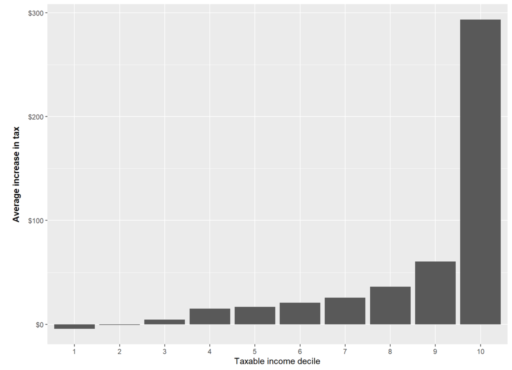

```r
library(ggplot2)
new_sample_file_1718 %>%
  mutate(Taxable_Income_decile = ntile(Taxable_Income, 10)) %>%
  group_by(Taxable_Income_decile) %>%
  summarise(`Average increase in tax` = mean(new_revenue - prv_revenue)) %>%
  arrange(Taxable_Income_decile) %>%
  #
  mutate(`Taxable income decile` = factor(Taxable_Income_decile)) %>%
  ggplot(aes(x = `Taxable income decile`, y = `Average increase in tax`)) +
  geom_bar(stat = "identity") +

  # cosmetic:
  scale_y_continuous(label = grattan_dollar) +
  theme(axis.title.y = element_text(face = "bold", angle = 90, margin = margin(1, 1, 1, 1, "lines")))

```

# Performance of project

To test the performance of our projection, we consider the projection of the 2012-13 sample file by one year with the actual 2013-14 sample file.

```r
sample_file_1314_projected <-
  sample_file_1213 %>%
  copy %>%
  mutate(WEIGHT = 50) %>%
  project(h = 1L,
          fy.year.of.sample.file = "2012-13",
          .recalculate.inflators = TRUE) %>%
  .[]
```

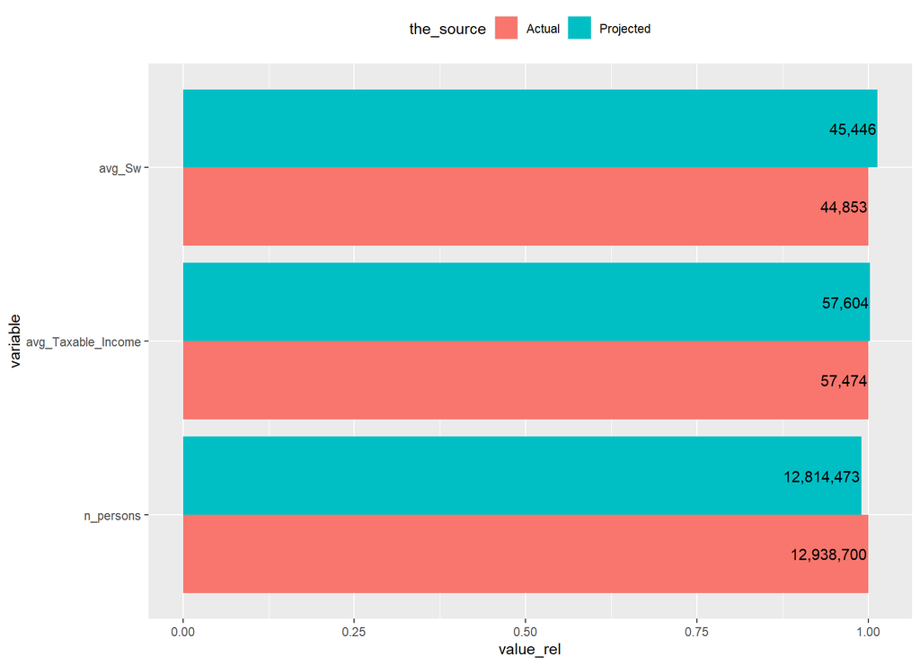

```r
data.table(the_source = c("Actual",
                          "Projected"),
           n_persons = c(nrow(sample_file_1314) * 50,
                         sum(sample_file_1314_projected$WEIGHT)),
           avg_Taxable_Income = c(mean(sample_file_1314$Taxable_Income),
                                  mean(sample_file_1314_projected$Taxable_Income)),
           avg_Sw = c(mean(sample_file_1314$Sw_amt),
                      mean(sample_file_1314_projected$Sw_amt))
) %>%
  melt.data.table(id.vars = "the_source") %>%
  group_by(variable) %>%
  mutate(value_rel = value / first(value)) %>%
  # dcast.data.table(variable ~ the_source) %>%
  ggplot(aes(x = variable, y = value_rel, fill = the_source)) +
  geom_bar(stat = "identity", position = "dodge") +
  geom_text(aes(label = comma(round(value))),
            position = position_dodge(width = 0.9),
            hjust = 1.02) +
  coord_flip() +
  theme(legend.position = "top")
```

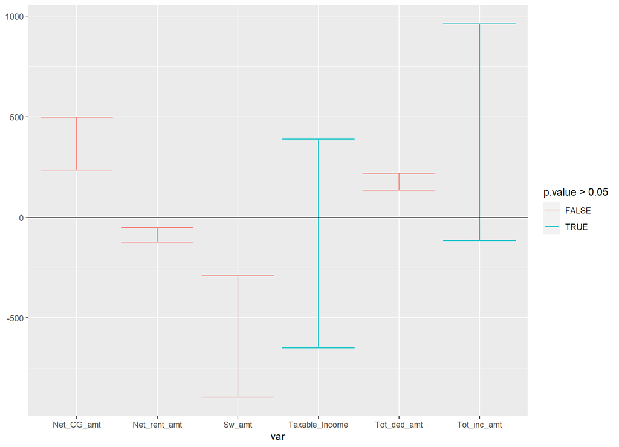

```r
conf_int_of_t.test <- function(variable){
  t_test <- t.test(sample_file_1314[[variable]],
                   sample_file_1314_projected[[variable]])

  data.table(var = variable,
             conf.low = t_test$conf.int[1],
             conf.high = t_test$conf.int[2],
             p.value = t_test$p.value)
}

c("Sw_amt",
  "Net_rent_amt",
  "Net_CG_amt",
  "Tot_inc_amt",
  "Tot_ded_amt",
  "Taxable_Income") %>%
  lapply(conf_int_of_t.test) %>%
  rbindlist %>%
  .[, list(var, conf.low, conf.high, p.value)] %>%
  ggplot(aes(x = var,
             ymin = conf.low,
             ymax = conf.high,
             color = p.value > 0.05)) +
  geom_errorbar() +
  geom_hline(yintercept = 0)
```

## Years not in sample files

Other tests can be found in the `tests/` folder to compare the tax collections in those years.